# Comparing Dissimilarity Indices using Current and Historical Metro Definitions

The goal of this research is to assess the sensitivity of measuring historical metropolitan segregation using present-day Core-Based Statistical Areas (CBSAs) in contrast to contemporaneous boundaries (for example, 1970 Standard Metropolitan Statistical Areas). The Census Bureau has changed the extent of what constitutes a metropolitan area in a given year over the past 40 years, and these boundary revisions complicate measuring metropolitan residential segregation over long periods of time (for example, 1970 to 2010).

## Preamble

We’ll start by loading the `tidyverse` package that covers `dplyr` (data manipulation), `ggplot` (data visualization), `stringr` (string manipulation) and `readr` (data import). Two spatial packages `rgdal` and `rgeos` provide functions for loading ESRI shapefiles and the geoprocessing tasks (compute centroid, point-in-polygon intersection) we will need to do to create a crosswalk table. Finally, `skimr` provides pipable functions for summary statistics that will be useful for analyzing agreement between measurement strategies.

```r
#libraries
library(tidyverse)
library(rgdal)
library(rgeos)
library(skimr)
```

Loading the data for this analysis requires two different steps. The first step is to load the NCDB into the R environment (NB: see [here](http://www.geolytics.com/USCensus,Neighborhood-Change-Database-1970-2000,Products.asp) for more information about obtaining a copy from Geolytics). Since this file is a .RData object, we use `load("path_to_filename.RData").`

The second step is to load in ESRI shapefiles corresponding to the MSA boundaries at a given point in time with `readOGR()`. We also load a 2010 Census Tract shapefile from NHGIS that we will use to place tracts within MSAs. These shapefiles are all freely obtained from [NHGIS](https://nhgis.org) and are accessed from a input directory within the main repository directory. To ensure spatial coordinates mean the same thing across data, we run a sanity check that all shapefiles return the same geographic projection type via `proj4string()`.

```r
#load in NCDB to extract CBSAs with (NB: RData untracked on github)
load(file = "./ncdb_workspace.RData")

#Standard Metropolitan Statistical Areas
smsa1970_shp <- readOGR(dsn = "./input/US_smsa_1970.shp",
                        layer = "US_smsa_1970",
                        verbose = FALSE,
                        stringsAsFactors = FALSE)

smsa1980_shp <- readOGR(dsn = "./input/US_smsa_1980.shp",
                        layer = "US_smsa_1980",
                        verbose = FALSE,
                        stringsAsFactors = FALSE)

#Metropolitan Statistical Areas & Consolidated Metropolitan Statistical Areas
cmsa1990_shp <- readOGR(dsn = "./input/US_msacmsa_1990.shp",
                        layer = "US_msacmsa_1990",
                        verbose = FALSE,
                        stringsAsFactors = FALSE)

cmsa2000_shp <- readOGR(dsn = "./input/US_msacmsa_2000.shp",
                        layer = "US_msacmsa_2000",
                        verbose = FALSE,
                        stringsAsFactors = FALSE)

#Primary Metropolitan Statistical Areas
pmsa1990_shp <- readOGR(dsn = "./input/US_pmsa_1990.shp",
                        layer = "US_pmsa_1990",
                        verbose = FALSE,
                        stringsAsFactors = FALSE)

pmsa2000_shp <- readOGR(dsn = "./input/US_pmsa_2000.shp",
                        layer = "US_pmsa_2000",
                        verbose = FALSE,
                        stringsAsFactors = FALSE)

#Core-Based Statistical Areas
cbsa2010_shp <- readOGR(dsn = "./input/US_cbsa_2010.shp",
                        layer = "US_cbsa_2010",
                        verbose = FALSE,
                        stringsAsFactors = FALSE)

#2010 Census Tracts
tract2010_shp <- readOGR(dsn = "./input/US_tract_2010.shp",
                        layer = "US_tract_2010",
                        verbose = FALSE,
                        stringsAsFactors = FALSE)

#sanity check that all shps geo projections are the same
proj4string(tract2010_shp) == proj4string(smsa1970_shp)
```

```
## [1] TRUE
```

```r
proj4string(tract2010_shp) == proj4string(smsa1980_shp)
```

```
## [1] TRUE
```

```r
proj4string(tract2010_shp) == proj4string(cmsa1990_shp)
```

```
## [1] TRUE
```

```r
proj4string(tract2010_shp) == proj4string(cmsa2000_shp)
```

```
## [1] TRUE
```

```r
proj4string(tract2010_shp) == proj4string(pmsa1990_shp)
```

```
## [1] TRUE
```

```r
proj4string(tract2010_shp) == proj4string(pmsa2000_shp)
```

```
## [1] TRUE
```

```r
proj4string(tract2010_shp) == proj4string(cbsa2010_shp)
```

```
## [1] TRUE
```

Lastly, we save a new operator like `>` and `==` with `%!in%`, which returns `TRUE` when LHS values being evaluated are not found in a value or set of values on the RHS.

```r
#not in operator
'%!in%' <- function(x,y)!('%in%'(x,y))

#examples
primary <- c("Blue", "Red", "Yellow")

"Blue" %in% primary
```

```
## [1] TRUE
```

```r
"Green" %in% primary
```

```
## [1] FALSE
```

```r
"Green" %!in% primary
```

```
## [1] TRUE
```

## Geoprocessing

There are two main features of the geoprocessing we need to do. First, we use `gCentroid()` from `rgeos` to compute each tract’s centroid according to the 2010 Census Tract shapefile we loaded. Once we initialize a `SpatialPointsDataFrame` where each set of coordinates corresponds to a unique tract, we use `over()` from the `sp` library (a dependency of `rgdal` and `rgeos`) to intersect each census tract point with the various MSA boundaries used from 1970-2000.

After computing the point-in-polygon intersections, we compile a table of tract IDs and the MSA boundaries the tract’s centroid fell within. If a tract did not fall within a boundary these measures take a value of `NA`. For 1990 and 2000 we use a conditional approach to identifying a tract’s MSA. If a tract was in a *Primary Metropolitan Statistical Area (PMSA)* we use that, otherwise we use the code found in the combined “MSA/CMSA Code” field of the CMSA90 and CMSA00 shapefiles. So if a tract was part of a *Consolidated Metropolitan Statistical Area (CMSA)* made up of multiple PMSAs, we use the lower-level PMSA code. Otherwise the CMSA code denotes a regular MSA which we use as the tract’s MSA value.

```r
centroids <- tract2010_shp@data

coordinates(centroids) <- gCentroid(tract2010_shp, byid=TRUE)@coords
proj4string(centroids) <- proj4string(tract2010_shp)

#1970 SMSA
SMSA70 <- over(centroids, smsa1970_shp[,"SMSAA"])
colnames(SMSA70) <- "SMSA70"

#1980 SMSA
SMSA80 <- over(centroids, smsa1980_shp[,"SMSAA"])
colnames(SMSA80) <- "SMSA80"

#1990 MSA/CMSA
CMSA90 <- over(centroids, cmsa1990_shp[,"MSACMSA"])
colnames(CMSA90) <- "CMSA90"

#2000 MSA/CMSA
CMSA00 <- over(centroids, cmsa2000_shp[,"MSACMSA"])
colnames(CMSA00) <- "CMSA00"

#1990 PMSA
PMSA90 <- over(centroids, pmsa1990_shp[,"PMSA"])
colnames(PMSA90) <- "PMSA90"

#2000 PMSA
PMSA00 <- over(centroids, pmsa2000_shp[,"PMSA"])
colnames(PMSA00) <- "PMSA00"

#compile a table of the centroid tract and MSA IDs
centroids <- bind_cols(centroids@data, SMSA70, SMSA80, CMSA90, PMSA90, CMSA00, PMSA00) %>%
  mutate(MSA70 = SMSA70,
         MSA80 = SMSA80,
         MSA90 = ifelse(is.na(PMSA90), CMSA90, PMSA90),
         MSA00 = ifelse(is.na(PMSA00), CMSA00, PMSA00))
```

## Compute Dissimilarity Indices

At this point we can almost compute the segregation measures. However, since we want non-Hispanic black and non-Hispanic white counts as the two population groups we need to create a comparable tract ID field for the NHGIS tract centroid table. The field `GEOID10` from NHGIS always has a length of 11 characters, but the NCDB counterpart `GEO2010` varies between 10 and 11 based on how many digits the state code is.

Fixing the difference in the string format boils down to padding the state and county components of the tract ID with 0s such that the pasted tract ID has 11 characters regardless of whether the state is 1 or 51. For the 6 digit tract component of the `GEOID10` we need to improvise a little since the NCDB does not provide the necessary field on its own. The final 6 digits of a tract FIPS code are the tract component, so the end of the pasted GEOID10 field we `mutate()` grabs either positions 5-10 or 6-11 of the `GEO2010` field based on the two character lengths that exist in `GEO2010`.

The spatially-matched table of tract centroids with MSA values joins to the NCDB for 99.6% of its tracts. The remaining unmatched tracts in the NCDB have “99000” tract codes and exist in counties where the NHGIS shapefile does not possess such tracts (i.e. does not seem to be a simple string formatting issue).

```r
#need to construct GEOID10 to have same str structure as NHGIS
ncdb_GEOID10 <- ncdb_vanilla %>%
  mutate(GEOID10 = paste0(str_pad(STATE, 2, "left", "0"),
                          str_pad(COUNTY, 3, "left", "0"),
                          ifelse(nchar(GEO2010) == 10, str_sub(GEO2010, 5, 10), str_sub(GEO2010, 6, 11)))) %>%
  select(GEOID10, GEO2010, PLACE, COUSUB) #make crosswalk for two forms of tract ID (NHGIS, NCDB) + COUSUB ID

#rename ncdb_interp geo2010 as GEO2010
ncdb_interp$GEO2010 <- ncdb_interp$geo2010

#1:1 join by NCDB tract ID GEO2010
ncdb <- inner_join(ncdb_interp, ncdb_GEOID10)
#1:1 join by NHGIS tract ID GEOID10
ncdb <- inner_join(ncdb, centroids)
#292/73057 still do not join. There are tract 990000 that exist in counties in NCDB that do not exist in
#the same STATE X COUNTY in NHGIS

#make the column name for CBSAs clearer
ncdb$CBSA <- ncdb$metroid

#Colonial Heights City has a one tract in Richmond SMSA---locating in Petersburg-Colonial Heights, VA SMSA until
#the rest of the county (i.e. 4 other tracts) make the switch to the Richmond PMSA in 1990
ncdb <- ncdb %>%
  mutate(SMSA70 = ifelse(state == 51 & county == 570 & COUSUB == 90948, "6140", SMSA70),
         SMSA80 = ifelse(state == 51 & county == 570 & COUSUB == 90948, "6140", SMSA80))
```

Computing the dissimilarity index takes four piped functions. Starting with the tract-level `ncdb`:

1. `filter(!is.na(MSAXX))` - remove tracts that don’t exist within the selected boundary
2. `group_by(MSAXX)` - group tracts by the selected boundary
3. `summarize(MSAXX_D_19XX = * sum(abs(tnhbt1970/sum(tnhbt1970) - tnhwt1970/sum(tnhwt1970))))`
- summarize each MSA’s segregation as
  $$\frac{1}{2} \times \sum_{i=1}^{N}{|\frac{\textrm{black}_{i}}{\textrm{black}_{metro}}-\frac{\textrm{white}_{i}}{\textrm{white}_{metro}}}|$$
  where i are tracts and there are N per MSA grouping.
- The denominator terms (e.g. `sum(tnhbt1970)`) are group-wise (as in MSA) sums of tract counts for a population group at a given time. These expressions evaluate to the $\textrm{black}_{metro}$ and $\textrm{white}_{metro}$ values needed for computing D.
4. `mutate_at()`- this is mutating the column made via summarize to recode as `NA` in the places where division by zero took place (creates `NaN` instead).

For the historical delineations we only compute the contemporaneous measure. For the 2010 CBSA definition, we compute measures of dissimilarity for 1970-2000.

```r
seg_1970msa <- ncdb %>%
  filter(!is.na(MSA70)) %>%
  group_by(MSA70) %>%
  summarize(MSA70_D_1970 = (.5) * sum(abs(tnhbt1970/sum(tnhbt1970) - tnhwt1970/sum(tnhwt1970)))) %>%
  mutate_at(.vars = vars(starts_with("MSA70_D")),
            .funs = function(x){ifelse(is.nan(x), NA, x)})

seg_1980msa <- ncdb %>%
  filter(!is.na(MSA80)) %>%
  group_by(MSA80) %>%
  summarize(MSA80_D_1980 = (.5) * sum(abs(tnhbt1980/sum(tnhbt1980) - tnhwt1980/sum(tnhwt1980)))) %>%
  mutate_at(.vars = vars(starts_with("MSA80_D")),
            .funs = function(x){ifelse(is.nan(x), NA, x)})

seg_1990msa <- ncdb %>%
  filter(!is.na(MSA90)) %>%
  group_by(MSA90) %>%
  summarize(MSA90_D_1990 = (.5) * sum(abs(tnhbt1990/sum(tnhbt1990) - tnhwt1990/sum(tnhwt1990)))) %>%
  mutate_at(.vars = vars(starts_with("MSA90_D")),
            .funs = function(x){ifelse(is.nan(x), NA, x)})

seg_2000msa <- ncdb %>%
  filter(!is.na(MSA00)) %>%
  group_by(MSA00) %>%
  summarize(MSA00_D_2000 = (.5) * sum(abs(tnhbt2000/sum(tnhbt2000) - tnhwt2000/sum(tnhwt2000)))) %>%
  mutate_at(.vars = vars(starts_with("MSA00_D")),
            .funs = function(x){ifelse(is.nan(x), NA, x)})

seg_2010cbsa <- ncdb %>%
  filter(!is.na(CBSA)) %>%
  group_by(CBSA) %>%
  summarize(CBSA_D_1970 = (.5) * sum(abs(tnhbt1970/sum(tnhbt1970) - tnhwt1970/sum(tnhwt1970))),
            CBSA_D_1980 = (.5) * sum(abs(tnhbt1980/sum(tnhbt1980) - tnhwt1980/sum(tnhwt1980))),
            CBSA_D_1990 = (.5) * sum(abs(tnhbt1990/sum(tnhbt1990) - tnhwt1990/sum(tnhwt1990))),
            CBSA_D_2000 = (.5) * sum(abs(tnhbt2000/sum(tnhbt2000) - tnhwt2000/sum(tnhwt2000))),
            tpopm1970 = sum(trctpop1970),
            tpopm1980 = sum(trctpop1980),
            tpopm1990 = sum(trctpop1990),
            tpopm2000 = sum(trctpop2000),
            tpopm2010 = sum(trctpop2010)) %>%
  mutate_at(.vars = vars(starts_with("CBSA_D")),
            .funs = function(x){ifelse(is.nan(x), NA, x)})

#NB: NAs in the 2010 CBSA table come from two sources
#1. tracts with 0 population at t -> CBSAs with 0 population at t
#2. NAs for tract population at t -> NA for dissimilarity at t
```

After computing individual tables with MSA codes and dissimilarity values we need to link the index values across years.

Within New England there is variation within counties but elsewhere a unique county may only have one MSA. This means we can safely collapse the units to describe unique counties. So for all analyses that follow there is a difference in units of analysis between New England and the rest of the US.

```r
#compute crosswalk table of counties according to the
seg_cw_NE <- ncdb %>%
  rename(STATE = state, COUNTY = county) %>%
  mutate(PLACE = ifelse(PLACE == "", NA, PLACE),
         NEWENG = STATE %in% c("9", "23", "25", "33", "44", "50")) %>%
  filter(NEWENG) %>%
  distinct(STATE, COUNTY, NEWENG, COUSUB, PLACE, MSA70, MSA80, MSA90, MSA00, CBSA)

seg_cw_nonNE <- ncdb %>%
  rename(STATE = state, COUNTY = county) %>%
  mutate(PLACE = ifelse(PLACE == "", NA, PLACE),
         NEWENG = STATE %in% c("9", "23", "25", "33", "44", "50")) %>%
  filter(!NEWENG) %>%
  mutate(COUSUB = NA, #does not vary by these fields so collapsing to county-level for nonNE
         PLACE = NA) %>%
  distinct(STATE, COUNTY, NEWENG, COUSUB, PLACE, MSA70, MSA80, MSA90, MSA00, CBSA)

seg_cw <- bind_rows(seg_cw_NE, seg_cw_nonNE)

#append segregation measures by CBSA values
seg_D <- left_join(seg_cw, seg_2010cbsa)
seg_D <- left_join(seg_D, seg_2000msa)
seg_D <- left_join(seg_D, seg_1990msa)
seg_D <- left_join(seg_D, seg_1980msa)
seg_D <- left_join(seg_D, seg_1970msa)
```

## Analyze measurement differences

### A note about units of analysis

A case outside of NE uniquely identifies a county in a given state and has the appropriate spatially matched MSA codes for each census period. It is best to think of the analyses outside of NE as related to counties, the share of counties that are in a historical MSA and also in a CBSA, correlation between a county’s matched dissimilarity values between two MSA definitions, etc.

A case in NE represents a unique city, town, Census Designated Place or unincoporated county subdivision. These lower-level areal summaries are required given that there can be two MSA codes for a given county in New England. It is best to think of analyses in NE as showing the share of city/town/suburbs within a given MSA vs CBSA delineation, the correlation between a city/town/suburb’s matched dissmilarity values between two MSA definitions, etc.

### Counts of units within MSAs / CBSAs

The first step of the analysis will be to take some summary statistics about the counties / sub-county units in the MSA or CBSA at a given point in time. These counts will be used to measure the ratio of counties / sub-county units in historical MSA definitions compare to CBSA definitions.

For CBSAs, we limit the data summary to those CBSAs that we already computed to have 50K or greater populations in 2010. This condition defines whether a CBSA is micropolitan or metropolitan at the time these delineations (and micropolitan areas) were introduced. So for comparison purposes we exclude micropolitan areas and focus on the metropolitan areas among all CBSAs when looking at CBSA size and its comparison to older metropolitan statistical area delineations.

```r
#number/prop of historical MSA counties in CBSA by decade
cbsa_sum <- seg_D %>%
  filter(tpopm2010 >= 50000) %>%
  group_by(NEWENG, CBSA) %>%
  summarize(nCBSA = n())

msa_sum_70 <- seg_D %>%
  filter(!is.na(MSA70)) %>%
  group_by(NEWENG, MSA70) %>%
  summarize(nMSA70 = n())

msa_sum_80 <- seg_D %>%
  filter(!is.na(MSA80)) %>%
  group_by(NEWENG, MSA80) %>%
  summarize(nMSA80 = n())

msa_sum_90 <- seg_D %>%
  filter(!is.na(MSA90)) %>%
  group_by(NEWENG, MSA90) %>%
  summarize(nMSA90 = n())

msa_sum_00 <- seg_D %>%
  filter(!is.na(MSA00)) %>%
  group_by(NEWENG, MSA00) %>%
  summarize(nMSA00 = n())

#join summaries about each CBSA's counties back to seg_D by each county's CBSA and MSA code
seg_D <- left_join(seg_D, msa_sum_70)
seg_D <- left_join(seg_D, msa_sum_80)
seg_D <- left_join(seg_D, msa_sum_90)
seg_D <- left_join(seg_D, msa_sum_00)
seg_D <- left_join(seg_D, cbsa_sum)
write_csv(seg_D, "./output/county_msa_cbsa_crosswalk.csv")

#make NEWENG levels clearer
seg_D$NEWENG <- factor(seg_D$NEWENG)
levels(seg_D$NEWENG) <- c("Outside N.E.", "New England") # c(FALSE, TRUE)
```

### Ratio of N Units MSA / N Units CBSA

This analysis takes the table of counties and counties / sub-county units and tries to understand the share of historical MSAs within present-day CBSAs.

Each row is deduplicated by CBSA and MSA combinations to describe a historical MSA-CBSA comparison (so a CBSA may appear multiple times but a MSAXX value only once). Since the measures of interest only vary by CBSA and historical MSAs, there is no loss of information in collapsing from county / sub-county units other than the IDs we’d use for crosswalking to smaller units. I filter the CBSA-MSA linked table to constrain comparisons to situations where all linked CBSAs would have a metropolitan population at the given point in time. Otherwise the ratios are confounded by cases where a county became a micropolitan CBSA in 2010. For example, Culpeper, VA is on the outskirts of Washington DC PMSA in 2000 (which contains 24 counties total) but became a micropolitan CBSA in 2010.

The `ratio` value between the number of counties in each delineation is generally less than 1, indicating when CBSAs are larger (i.e. have more counties or county subdivisions in NE) than historical MSA definitions. Nonetheless, there are instances where the CBSA is the same number of counties/county subdivisions and also some where they are smaller than the historical MSA. For example, Boulder, CO now has its own CBSA of one county, but in 1970 and 1980 it was part of the 6 and then 7 county Denver SMSA.

Outside of New England, the 2000 boundaries end up being a little larger on average than CBSA boundaries in terms of counties, though the median value is parity between these counts.

#### 1970

```r
seg_D %>%
  filter(!is.na(MSA70), tpopm1970 > 50000) %>%
  group_by(NEWENG, CBSA, MSA70) %>%
  distinct(NEWENG, CBSA, MSA70, .keep_all = T) %>%
  summarize(ratio = nMSA70/nCBSA) %>%
  group_by(NEWENG) %>%
  select(ratio) %>%
  skim() %>%
  skimr::kable()
```

Skim summary statistics  
n obs: 261  
n variables: 2

Variable type: numeric

| NEWENG | variable | missing | complete | n | mean | sd | p0 | p25 | p50 | p75 | p100 | hist |
| --- | --- | --- | --- | --- | --- | --- | --- | --- | --- | --- | --- | --- |
| Outside N.E. | ratio | 0 | 227 | 227 | 0.72 | 0.66 | 0.033 | 0.33 | 0.5 | 1 | 7 |  |
| New England | ratio | 0 | 34 | 34 | 0.24 | 0.19 | 0.024 | 0.088 | 0.19 | 0.37 | 0.77 |  |

#### 1980

```r
seg_D %>%
  filter(!is.na(MSA80), tpopm1980 > 50000) %>%
  group_by(NEWENG, CBSA, MSA80) %>%
  distinct(NEWENG, CBSA, MSA80, .keep_all = T) %>%
  summarize(ratio = nMSA80/nCBSA) %>%
  group_by(NEWENG) %>%
  select(ratio) %>%
  skim() %>%
  skimr::kable()
```

Skim summary statistics  
n obs: 364  
n variables: 2

Variable type: numeric

| NEWENG | variable | missing | complete | n | mean | sd | p0 | p25 | p50 | p75 | p100 | hist |
| --- | --- | --- | --- | --- | --- | --- | --- | --- | --- | --- | --- | --- |
| Outside N.E. | ratio | 0 | 316 | 316 | 0.93 | 0.89 | 0.033 | 0.5 | 0.82 | 1 | 9 |  |
| New England | ratio | 0 | 48 | 48 | 0.41 | 0.41 | 0.026 | 0.13 | 0.3 | 0.5 | 2.04 |  |

#### 1990

```r
seg_D %>%
  filter(!is.na(MSA90), tpopm1990 > 50000) %>%
  group_by(NEWENG, CBSA, MSA90) %>%
  distinct(NEWENG, CBSA, MSA90, .keep_all = T) %>%
  summarize(ratio = nMSA90/nCBSA) %>%
  group_by(NEWENG) %>%
  select(ratio) %>%
  skim() %>%
  skimr::kable()
```

Skim summary statistics  
n obs: 389  
n variables: 2

Variable type: numeric

| NEWENG | variable | missing | complete | n | mean | sd | p0 | p25 | p50 | p75 | p100 | hist |
| --- | --- | --- | --- | --- | --- | --- | --- | --- | --- | --- | --- | --- |
| Outside N.E. | ratio | 0 | 336 | 336 | 0.95 | 0.99 | 0.033 | 0.5 | 0.75 | 1 | 7 |  |
| New England | ratio | 0 | 53 | 53 | 0.44 | 0.5 | 0.0043 | 0.11 | 0.32 | 0.5 | 2.07 |  |

#### 2000

```r
seg_D %>%
  filter(!is.na(MSA00), tpopm2000 > 50000) %>%
  group_by(NEWENG, CBSA, MSA00) %>%
  distinct(NEWENG, CBSA, MSA00, .keep_all = T) %>%
  summarize(ratio = nMSA00/nCBSA) %>%
  group_by(NEWENG) %>%
  select(ratio) %>%
  skim() %>%
  skimr::kable()
```

Skim summary statistics  
n obs: 407  
n variables: 2

Variable type: numeric

| NEWENG | variable | missing | complete | n | mean | sd | p0 | p25 | p50 | p75 | p100 | hist |
| --- | --- | --- | --- | --- | --- | --- | --- | --- | --- | --- | --- | --- |
| Outside N.E. | ratio | 0 | 362 | 362 | 1.27 | 1.41 | 0.033 | 0.5 | 1 | 1 | 9 |  |
| New England | ratio | 0 | 45 | 45 | 0.76 | 0.86 | 0.039 | 0.32 | 0.47 | 0.67 | 4.15 |  |

### Correlation of D using historical and CBSA delineations

#### 1970

```r
seg_D %>%
  filter(!is.na(MSA70), tpopm1970 > 50000) %>%
  group_by(NEWENG) %>%
  summarize(cor70 = cor(MSA70_D_1970, CBSA_D_1970, use = "complete.obs")) %>%
  knitr::kable()
```

| NEWENG | cor70 |
| --- | --- |
| Outside N.E. | 0.9402912 |
| New England | 0.5605521 |

#### 1980

```r
seg_D %>%
  filter(!is.na(MSA80), tpopm1980 > 50000) %>%
  group_by(NEWENG) %>%
  summarize(cor80 = cor(MSA80_D_1980, CBSA_D_1980, use = "complete.obs")) %>%
  knitr::kable()
```

| NEWENG | cor80 |
| --- | --- |
| Outside N.E. | 0.9220354 |
| New England | 0.5889243 |

#### 1990

```r
seg_D %>%
  filter(!is.na(MSA90), tpopm1990 > 50000) %>%
  group_by(NEWENG) %>%
  summarize(cor90 = cor(MSA90_D_1990, CBSA_D_1990, use = "complete.obs")) %>%
  knitr::kable()
```

| NEWENG | cor90 |
| --- | --- |
| Outside N.E. | 0.8848420 |
| New England | 0.5063569 |

#### 2000

```r
seg_D %>%
  filter(!is.na(MSA00), tpopm2000 > 50000) %>%
  group_by(NEWENG) %>%
  summarize(cor00 = cor(MSA00_D_2000, CBSA_D_2000, use = "complete.obs")) %>%
  knitr::kable()
```

| NEWENG | cor00 |
| --- | --- |
| Outside N.E. | 0.8960335 |
| New England | 0.6403891 |

### Summary statistics of D distributions

This section shows a county-level analysis (sub-county units for New England) of the black-white dissimilarity distribution under different delineations. A county must exist within a historical boundary to appear in a given summary computation. Like before, all comparisons are for counties among metropolitan areas as would be defined by either delineation at the given time point.

#### 1970

```r
seg_D %>%
  filter(!is.na(MSA70), tpopm1970 > 50000) %>%
  group_by(NEWENG) %>%
  select(MSA70_D_1970, CBSA_D_1970) %>%
  skim() %>%
  skimr::kable()
```

Skim summary statistics  
n obs: 846  
n variables: 3

Variable type: numeric

| NEWENG | variable | missing | complete | n | mean | sd | p0 | p25 | p50 | p75 | p100 | hist |
| --- | --- | --- | --- | --- | --- | --- | --- | --- | --- | --- | --- | --- |
| Outside N.E. | CBSA_D_1970 | 2 | 454 | 456 | 0.73 | 0.12 | 0.3 | 0.66 | 0.77 | 0.81 | 0.91 |  |
| Outside N.E. | MSA70_D_1970 | 7 | 449 | 456 | 0.73 | 0.11 | 0.39 | 0.66 | 0.76 | 0.81 | 0.95 |  |
| New England | CBSA_D_1970 | 0 | 390 | 390 | 0.71 | 0.072 | 0.53 | 0.69 | 0.75 | 0.77 | 0.77 |  |
| New England | MSA70_D_1970 | 8 | 382 | 390 | 0.7 | 0.11 | 0.39 | 0.62 | 0.73 | 0.79 | 0.82 |  |

#### 1980

```r
seg_D %>%
  filter(!is.na(MSA80), tpopm1980 > 50000) %>%
  group_by(NEWENG) %>%
  select(MSA80_D_1980, CBSA_D_1980) %>%
  skim() %>%
  skimr::kable()
```

Skim summary statistics  
n obs: 1227  
n variables: 3

Variable type: numeric

| NEWENG | variable | missing | complete | n | mean | sd | p0 | p25 | p50 | p75 | p100 | hist |
| --- | --- | --- | --- | --- | --- | --- | --- | --- | --- | --- | --- | --- |
| Outside N.E. | CBSA_D_1980 | 0 | 692 | 692 | 0.65 | 0.12 | 0.29 | 0.57 | 0.67 | 0.74 | 0.89 |  |
| Outside N.E. | MSA80_D_1980 | 0 | 692 | 692 | 0.65 | 0.12 | 0.29 | 0.56 | 0.67 | 0.74 | 0.89 |  |
| New England | CBSA_D_1980 | 0 | 535 | 535 | 0.66 | 0.1 | 0.35 | 0.57 | 0.7 | 0.75 | 0.75 |  |
| New England | MSA80_D_1980 | 0 | 535 | 535 | 0.64 | 0.14 | 0.33 | 0.54 | 0.68 | 0.76 | 0.77 |  |

#### 1990

```r
seg_D %>%
  filter(!is.na(MSA90), tpopm1990 > 50000) %>%
  group_by(NEWENG) %>%
  select(MSA90_D_1990, CBSA_D_1990) %>%
  skim() %>%
  skimr::kable()
```

Skim summary statistics  
n obs: 1340  
n variables: 3

Variable type: numeric

| NEWENG | variable | missing | complete | n | mean | sd | p0 | p25 | p50 | p75 | p100 | hist |
| --- | --- | --- | --- | --- | --- | --- | --- | --- | --- | --- | --- | --- |
| Outside N.E. | CBSA_D_1990 | 0 | 712 | 712 | 0.61 | 0.12 | 0.22 | 0.53 | 0.62 | 0.69 | 0.87 |  |
| Outside N.E. | MSA90_D_1990 | 0 | 712 | 712 | 0.61 | 0.12 | 0.22 | 0.52 | 0.61 | 0.69 | 0.89 |  |
| New England | CBSA_D_1990 | 0 | 628 | 628 | 0.62 | 0.094 | 0.4 | 0.52 | 0.69 | 0.69 | 0.7 |  |
| New England | MSA90_D_1990 | 0 | 628 | 628 | 0.58 | 0.12 | 0 | 0.5 | 0.54 | 0.7 | 0.75 |  |

#### 2000

```r
seg_D %>%
  filter(!is.na(MSA00), tpopm2000 > 50000) %>%
  group_by(NEWENG) %>%
  select(MSA00_D_2000, CBSA_D_2000) %>%
  skim() %>%
  skimr::kable()
```

Skim summary statistics  
n obs: 1522  
n variables: 3

Variable type: numeric

| NEWENG | variable | missing | complete | n | mean | sd | p0 | p25 | p50 | p75 | p100 | hist |
| --- | --- | --- | --- | --- | --- | --- | --- | --- | --- | --- | --- | --- |
| Outside N.E. | CBSA_D_2000 | 0 | 813 | 813 | 0.56 | 0.13 | 0.23 | 0.46 | 0.56 | 0.65 | 0.85 |  |
| Outside N.E. | MSA00_D_2000 | 0 | 813 | 813 | 0.56 | 0.13 | 0.23 | 0.47 | 0.57 | 0.65 | 0.85 |  |
| New England | CBSA_D_2000 | 0 | 709 | 709 | 0.57 | 0.12 | 0.28 | 0.51 | 0.64 | 0.66 | 0.68 |  |
| New England | MSA00_D_2000 | 0 | 709 | 709 | 0.55 | 0.12 | 0.26 | 0.47 | 0.58 | 0.66 | 0.73 |  |

### Counties with exact same and within value for MSA and CBSA measures

This counties / sub-county units analysis quantifies the absolute amount of disagreement between the two measures with the proportion falling within exact match, <.01 and <.05 thresholds.

#### 1970

```r
seg_D %>%
  filter(!is.na(MSA70_D_1970), !is.na(CBSA_D_1970), tpopm1970 >= 50000) %>% #need to filter out the NAs created by division by 0 in CBSA col
  mutate(same = MSA70_D_1970 == CBSA_D_1970,            #there are CBSAs with no population coverage in 1970
         within_01 = abs(MSA70_D_1970 - CBSA_D_1970) < .01,
         within_05 = abs(MSA70_D_1970 - CBSA_D_1970) < .05) %>%
  group_by(NEWENG) %>%
  summarize(nSame = sum(same),
            nWithin_01 = sum(within_01),
            nWithin_05 = sum(within_05),
            nTot = n(),
            propSame = nSame/nTot,
            propWithin_01 = nWithin_01/nTot,
            propWithin_05 = nWithin_05/nTot) %>%
  knitr::kable()
```

| NEWENG | nSame | nWithin_01 | nWithin_05 | nTot | propSame | propWithin_01 | propWithin_05 |
| --- | --- | --- | --- | --- | --- | --- | --- |
| Outside N.E. | 214 | 356 | 406 | 449 | 0.4766147 | 0.7928731 | 0.9042316 |
| New England | 0 | 38 | 319 | 382 | 0.0000000 | 0.0994764 | 0.8350785 |

#### 1980

```r
seg_D %>%
  filter(!is.na(MSA80_D_1980), tpopm1980 >= 50000) %>%
  mutate(same = MSA80_D_1980 == CBSA_D_1980,
         within_01 = abs(MSA80_D_1980 - CBSA_D_1980) < .01,
         within_05 = abs(MSA80_D_1980 - CBSA_D_1980) < .05) %>%
  group_by(NEWENG) %>%
  summarize(nSame = sum(same),
            nWithin_01 = sum(within_01),
            nWithin_05 = sum(within_05),
            nTot = n(),
            propSame = nSame/nTot,
            propWithin_01 = nWithin_01/nTot,
            propWithin_05 = nWithin_05/nTot) %>%
  knitr::kable()
```

| NEWENG | nSame | nWithin_01 | nWithin_05 | nTot | propSame | propWithin_01 | propWithin_05 |
| --- | --- | --- | --- | --- | --- | --- | --- |
| Outside N.E. | 306 | 514 | 631 | 692 | 0.4421965 | 0.7427746 | 0.9118497 |
| New England | 0 | 47 | 317 | 535 | 0.0000000 | 0.0878505 | 0.5925234 |

#### 1990

```r
seg_D %>%
  filter(!is.na(MSA90_D_1990), tpopm1990 > 50000) %>%
  mutate(same = MSA90_D_1990 == CBSA_D_1990,
         within_01 = abs(MSA90_D_1990 - CBSA_D_1990) < .01,
         within_05 = abs(MSA90_D_1990 - CBSA_D_1990) < .05) %>%
  group_by(NEWENG) %>%
  summarize(nSame = sum(same),
            nWithin_01 = sum(within_01),
            nWithin_05 = sum(within_05),
            nTot = n(),
            propSame = nSame/nTot,
            propWithin_01 = nWithin_01/nTot,
            propWithin_05 = nWithin_05/nTot) %>%
  knitr::kable()
```

| NEWENG | nSame | nWithin_01 | nWithin_05 | nTot | propSame | propWithin_01 | propWithin_05 |
| --- | --- | --- | --- | --- | --- | --- | --- |
| Outside N.E. | 152 | 402 | 618 | 712 | 0.2134831 | 0.5646067 | 0.8679775 |
| New England | 0 | 151 | 360 | 628 | 0.0000000 | 0.2404459 | 0.5732484 |

#### 2000

```r
seg_D %>%
  filter(!is.na(MSA00_D_2000), tpopm2000 > 50000) %>%
  mutate(same = MSA00_D_2000 == CBSA_D_2000,
         within_01 = abs(MSA00_D_2000 - CBSA_D_2000) < .01,
         within_05 = abs(MSA00_D_2000 - CBSA_D_2000) < .05) %>%
  group_by(NEWENG) %>%
  summarize(nSame = sum(same),
            nWithin_01 = sum(within_01),
            nWithin_05 = sum(within_05),
            nTot = n(),
            propSame = nSame/nTot,
            propWithin_01 = nWithin_01/nTot,
            propWithin_05 = nWithin_05/nTot) %>%
  knitr::kable()
```

| NEWENG | nSame | nWithin_01 | nWithin_05 | nTot | propSame | propWithin_01 | propWithin_05 |
| --- | --- | --- | --- | --- | --- | --- | --- |
| Outside N.E. | 158 | 484 | 736 | 813 | 0.1943419 | 0.5953260 | 0.9052891 |
| New England | 0 | 244 | 537 | 709 | 0.0000000 | 0.3441467 | 0.7574048 |

## Visualize measurement differences

This county / county subdivision analysis graphs the agreement between historical and CBSA dissimilarity indices. Note the 2D binning on this plot to show the point density around the slope=1 line.

Mobile, AL is the outlier with a much lower CBSA value of D than its SMSA70 and SMSA80 values of D. The 1970-2000 historical definitions include Baldwin County, AL in the Mobile, AL SMSA but CBSA delineations include this county in a new Daphne-Fairhope-Foley, AL micropolitan area.

#### 1970

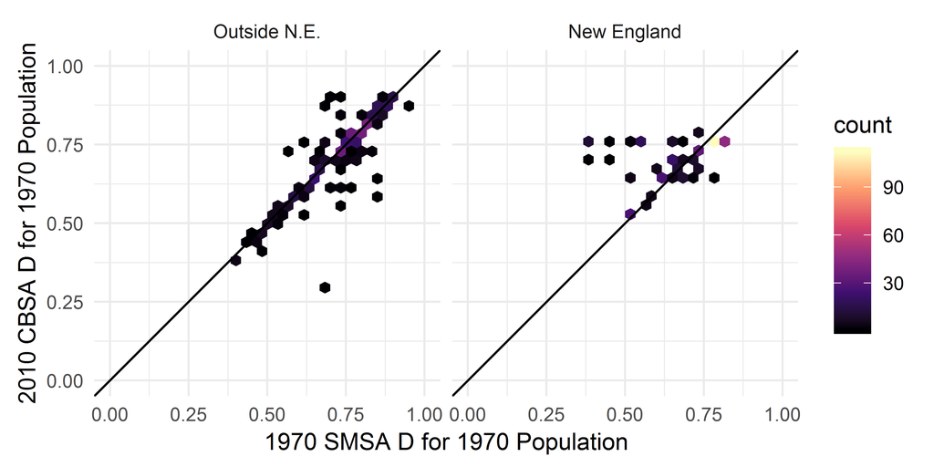

#### 1980

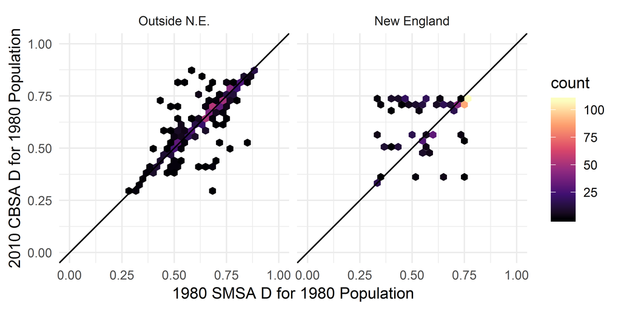

#### 1990

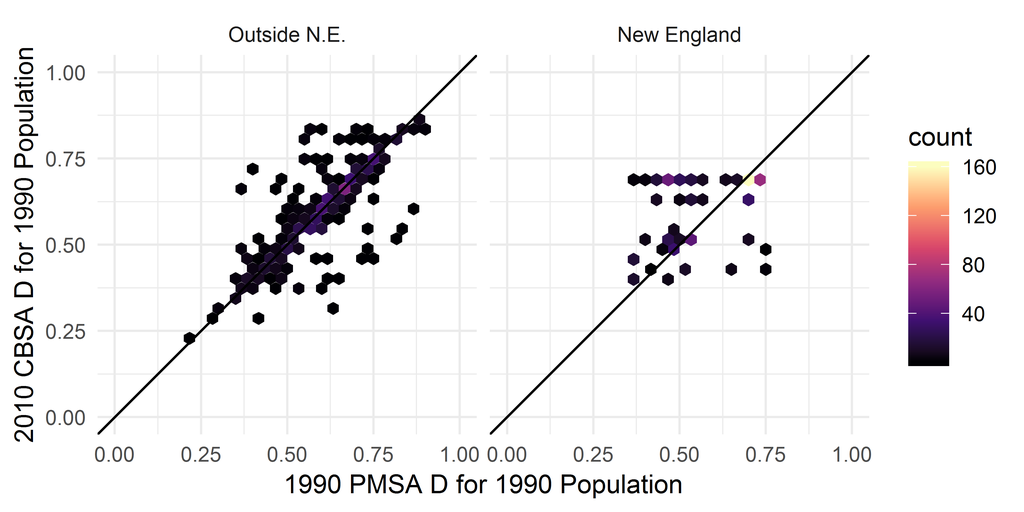

#### 2000

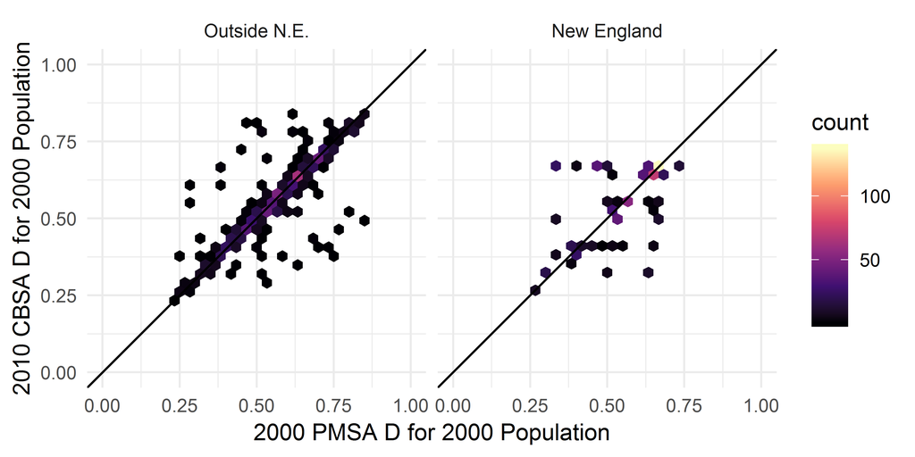